# Proyecto Final

Silvia Chaves-Ramírez

# Pregunta de investigación

¿El tamaño de los ámbitos de descanso de los grupos *Thyroptera tricolor* está infuenciado por el tamaño del grupo?

*Thyroptera tricolor* es una especie de murciélago que forma grupos sociales para refugiarse (Chaverri, Gillam, and Vonhof 2010). Esta especie utiliza hojas tubulares en crecimiento del orden zingiberales como refugio (Findley and Wilson 1974), al ser éstas un recurso efímero,sus ocupantes se ven obligados a buscar un nuevo refugio diariamente.Estudios anteriores han demostrado que los grupos de *T.tricolor* mantienen pequeños ámbitos de descanso con alta disponibilidad de refugios (Vonhof, Whitehead, and Fenton 2004).También existe evidencia de que cuando se elimina un pache utilizado por un grupo, este no utilizan los parches ocupados por sus vecinos y prefieren viajar lejos en busca de hojas disponibles (Chaverri and Kunz 2011). Estos patrones sugieren que *T.tricolor* es una especie territorial, sin embargo, hasta la fecha no existe ningún estudio que ponga a prueba esta hipóstesis.Por lo que es necesario entender mejor los patrones de uso del espacio para refugiarse y estudiar como estos pueden ser afectados por el tamaño de los grupos y así como la disponibilidad de los refugios.

Para este proyecto de investigación voy enfocarme en entender como el tamaño del grupo puede afectar los patrones de uso del espacio. Para lo cual voy a simular la disponibilidad de refugios para *T. tricolor* en un hábitat y apartir de ahí voy a extraer datos espaciales simulados de recapturas de grupos de murciélagos en los refugios. Luego voy a estimar los ámbitos de descanso para diferentes grupos.Por último voy aplicar un modelo lineal para determinar el efecto del tamaño del grupo sobre el tamaño de los ámbitos de descanso.

**Hipótesis**: En animales territoriales los grupos más numerosos suelen ocupar ámbitos de hogar más grandes y con mayor cantidad de recursos, ya que al ser más numerosos pueden defender mejor un área.

**Predicción:** Si *T.tricolor* es una especie territorial, espero encontrar que entre más grande sea el grupo mayor será el ámbito de descanso.

# Diagrama causal

Quiero conocer el efecto directo del tamaño del grupo sobre el tamaño de los ámbitos de descanso de los grupos de *Thyroptera tricolor* (AD).Sin embargo, la disponibilidad de refugios(H) en el ambiente, también podría estar influenciando positivamente el tamaño de los ámbitos de descanso en esta especie.

```
## # A DAG with 3 nodes and 2 edges
## #
## # Exposure: TG
## # Outcome: AD
## #
## # A tibble: 3 x 8
##   name      x     y direction to     xend  yend circular
##   <chr> <dbl> <dbl> <fct>     <chr> <dbl> <dbl> <lgl>
## 1 H      26.1  31.1 ->        AD     27.2  30.6 FALSE
## 2 TG     28.3  30.2 ->        AD     27.2  30.6 FALSE
## 3 AD     27.2  30.6 <NA>      <NA>   NA    NA   FALSE
```

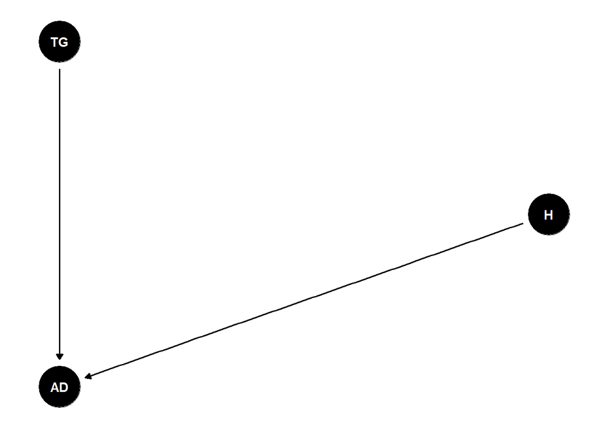

# Código de simulación

### Simulación de hábitat para grupos de *T.tricolor*.

Para simular datos aleatorios que similares al patrón de distribución de hojas disponibles como refugios y las ubicaciones de grupos de *T.tricolor* observado en la naturaleza, apliqué un movimiento Browniano estandar, como se detalla a continuación:

```r
# Se cargan los paquetes necesarios para los análisis


library(adehabitatHR) # Home Range Estimation
library(ggplot2)
library(gridExtra)

#Funciones-----------

#Simulación de Hábitat ---

#En esta función  es para generar las hojas disponibles como refugios dentro de un área de muestreo  200 x 300 m2. También crean las variables para el número de grupos,  número de individuos por grupo

sim_habitat <- function(n_groups, n_indiv, n_leaves = 3000, steps = 10000, sig2 = 0.7, plot = TRUE, xlim = c(0, 300), ylim = c(0, 200)) {


  if (n_leaves >= steps){
    cat(crayon::green(' Alto ahí, no se puede tener más hojas que steps\n'))
  stop()
}

t <- 0:steps  # Saltos de tiempo  en el que varia la distribución de hojas en el espacio

## Primero, se crea un set simulación de desviaciones con σ2= 0.7, para los valores de x
x <- rnorm(n = length(t) - 1, sd = sqrt(sig2))

## Ahora se  calcula la suma acumulada de las desviaciones
cx <- c(0, cumsum(x))
 plot(t, cx, type = "l", ylim = range(cx))

## Se repiten los dos pasos anteriores para los valores de y
y <- rnorm(n = length(t) - 1, sd = sqrt(sig2))
## suma acumulada de las desviaciones para valores de y
cy <- c(0, cumsum(y))

# Simulación de hojas disponibles como refugios---

sel_positions_x <- cumsum((rbinom(n_leaves, size = 2, prob = 0.1) * 400) + 50)
sel_positions_y <- cumsum((rbinom(n_leaves, size = 2, prob = 0.1) * 400) + 50)

sel_positions_x <- (sel_positions_x / max(sel_positions_x)) * steps
sel_positions_y <- (sel_positions_y / max(sel_positions_y)) * steps

slxs <- cx[sel_positions_x]
slys <- cy[sel_positions_y]

# Obtenemos las coordenadas  para el número de hojas disponibles como refugio dentro de los limites del área de estudio  200 x300 m2
slxs <- slxs + abs(min(slxs))
slxs <- (slxs / max(slxs)) * xlim[2]
slys <- slys + abs(min(slys))
slys <- (slys / max(slys)) * ylim[2]

# Se guardan las coordenadas de las hojas en  un data frame
coor_df <- data.frame(lon= slxs, lat = slys)

if (plot)
plot(coor_df$lon, coor_df$lat, pch = 20, col = adjustcolor("green", alpha.f = 0.3), xlim = xlim + c(-10, 10), ylim = ylim + c(-10, 10))


return(coor_df)
}

# Simulación ubicación de grupos---

# Simular las coordenadas de ubicación para 10 grupos de murciélagos
ubi_groups <- function(leaf_coors, groups, radius_constant = 6){

    if (groups >= nrow(leaf_coors)){
    cat(crayon::green('No se puede tener más grupos q hojas \n'))
  stop()
}
# Aleatorizar el tamaño  para los 10 grupos con una  probabilidad que permita  obtener  valores similares a los de los grupos  en la naturaleza.

  group_sizes <- rbinom(n = groups, 10, prob = 0.6)

# extraemos una hoja central para cada grupo
  leaves <- sample(1:nrow(leaf_coors), length(group_sizes))
# obtenemos  las coordenanadas para cada hoja central
  centers <- leaf_coors[leaves, ]

  centers$group_size <- group_sizes

  centers$leaves <- leaves

# Se calculan todas las distancias posibles entre la hoja central  mediante una matriz de distancia  entre las hojas disponibles.
  dist_leaves <- as.matrix(dist(leaf_coors))

  group_leaves_l <- lapply(1:nrow(centers), function(x){

    dists_to_center <- dist_leaves[centers$leaves[x], ]

# Se seleccionan las hojas  cuya distancia al centro sea proporcion tamaño del grupo multiplicado por un radio constante.
    selec_leaves <- dists_to_center[dists_to_center < centers$group_size[x] * radius_constant]

# Se crea un data frame de las hojas selecionadas y sus respectivas coordenadas.
    selec_leaves_df <- leaf_coors[names(selec_leaves), ]

    selec_leaves_df$leaf_id <- names(selec_leaves)

    selec_leaves_df$dist_to_center <- selec_leaves

    selec_leaves_df$group_size <- centers$group_size[x]

    selec_leaves_df$id <- x

    return(selec_leaves_df)

  })
  group_leaves <- do.call(rbind, group_leaves_l)

 return(group_leaves) # Asumimos que todas las hojas que se seleccionan aleatoriamente entreel radio y  la hoja central forman parte de los ámbitos de descanso de cada grupo.
}

#Estimación de ámbitos de descanso  de Kernel---

#Función para obtener  determinar estimar los ámbitos de descanso para cada grupo,  con un 95% de confianza.

get_home_range <- function(X, percent = 95){

# Para utilizar las funciones del paquete "adehabitatHR" las coordenadas de los grupos deben convertirse en un objeto de clase SpatialPointsDataFrame

  Y <- SpatialPointsDataFrame(X[, c("lat", "lon")], as.data.frame(X$id))

# Se estima los ámbitos de descanso mediante un  la funcion #?kernelUD() que estima la probabilidad de densidad de kernel

  ud <- try(kernelUD(Y), silent = TRUE)

  areas <- unlist(as.data.frame(kernel.area(ud, percent = percent))[1,, drop = TRUE])

# Esta  función devuelve las áreas de los  ámbitos de hogar para cada grupo  para cada  grupo

  areas_df <- data.frame(group = 1:length(areas), area = areas, group_size = sapply(unique(X$id), function(e) X$group_size[X$id == e][1]))

  return(areas_df)
}


### Submuestreo
#   Para  verificar  ssi el resultado obtenido para  el modelo  de la relación entre el tamaño del grupo y el tamaño del ambito se mantiene.
resample_leaves <- function(X, n = 30){

  out <- lapply(unique(X$id), function(x){

    Y <- X[X$id == x, ]

    if (nrow(Y) > n)
      Y <- Y[sample(1:nrow(Y), n), ]

    return(Y)

  })

  return(do.call(rbind, out))

}
```

### Estimación de ámbitos de descanso

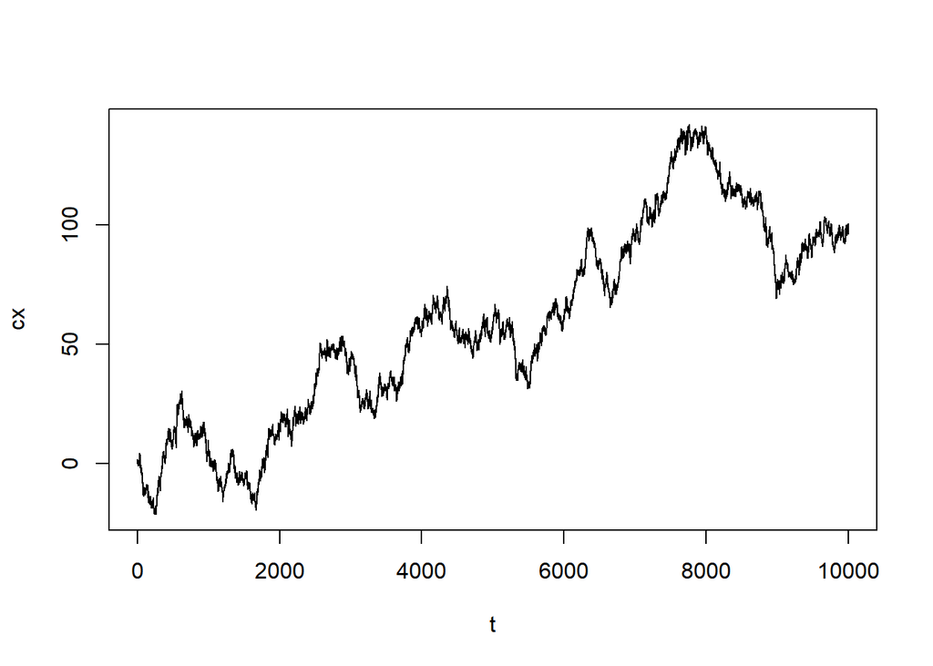

```r
# Se asume que las  coordenadas  de las hojas simuladas son reubicaciónes de grupos  dentro de los ambitos de descanso para 10 grupos

leaf_coors <- sim_habitat(n_leaves = 1000, plot = FALSE)
```

```r
sims <- ubi_groups(leaf_coors = leaf_coors, groups = 10, radius_constant = 6)

tab <- table(sims$id)

sims <- sims[!sims$id %in% names(tab[tab < 5]), ]

#  Se crea un set de datos  que contiene el área del ámbito de descanso y el número de individuos para cada grupo

range_and_size <- get_home_range(X = sims)
```

# Análisis

Para determinar el efecto que tiene el tamaño del grupo sobre el tamaño de los ámbitos de descanso de *t.tricolor* realicé modelo lineal utilizando como variable de respuesta el tamaño del ámbito de descanso y como variable predictora el número de individuos que componen los grupos . Luego apliqué un el mismo modelo para un submuestreo de 30 reubicaciones, con el fin de verificar si el patrón obtenido se mantiene con el mínimo de reubicaciones recomendadas para los anamisis de estimación de ambitos de Hogar utilizando modelos probabilidad de desnidad de kernel.

```r
mod <- lm(area ~ group_size, data = range_and_size)
summary(mod)
```

```
##
## Call:
## lm(formula = area ~ group_size, data = range_and_size)
##
## Residuals:
##      Min       1Q   Median       3Q      Max
## -0.16300 -0.02322  0.00070  0.03996  0.12730
##
## Coefficients:
##             Estimate Std. Error t value Pr(>|t|)
## (Intercept) -0.58388    0.20611  -2.833   0.0221 *
## group_size   0.16469    0.03524   4.673   0.0016 **
## ---
## Signif. codes:  0 '***' 0.001 '**' 0.01 '*' 0.05 '.' 0.1 ' ' 1
##
## Residual standard error: 0.0834 on 8 degrees of freedom
## Multiple R-squared:  0.7319, Adjusted R-squared:  0.6983
## F-statistic: 21.84 on 1 and 8 DF,  p-value: 0.001597
```

[output not shown]

[output not shown]

# Interpretación de resultados

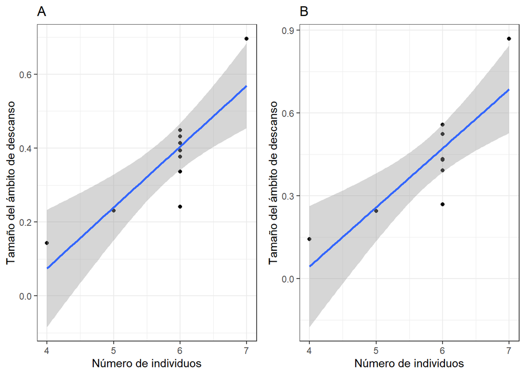

**Figura.1**.A y B muestran la relación entre el número de individuos y el tamaño de sus ámbitos de descanso . En B se representa el submuestreo con un tamaño de muestra de 30. Las leas azules representan la tendencia general de los datos y las bandas sombreadas el intervalo de confianza al 95%.

### Referencias

Chaverri, Gloriana, Erin H. Gillam, and Maarten J. Vonhof. 2010. “Social calls used by a leaf-roosting bat to signal location.” *Biology Letters* 6 (4): 441–44. https://doi.org/10.1098/rsbl.2009.0964.

Chaverri, Gloriana, and Thomas H. Kunz. 2011. “Response of a specialist bat to the loss of a critical resource.” *PLoS ONE* 6 (12): 1–10. https://doi.org/10.1371/journal.pone.0028821.

Findley, James, and Don Wilson. 1974. “Observations on the neotropical disk-winged bat, Thyroptera tricolor pinx.” *Journal of Mammalogy* 55 (3): 562–71. [https://doi.org/10.2307 / 1379546](https://doi.org/10.2307%20/%201379546).

Vonhof, Maarten J., Hal Whitehead, and M. Brock Fenton. 2004. “Analysis of Spix’s disc-winged bat association patterns and roosting home ranges reveal a novel social structure among bats.” *Animal Behaviour* 68 (3): 507–21. https://doi.org/10.1016/j.anbehav.2003.08.025.